# Peer Assessment 1: Reproducible Research

irv

Sunday, September 20, 2015

## Introduction

The problem presented was to perform simple analysis on movement data from a simple health tracking device such as a FitBit or similar item. Data provided (in csv format) gives a count of steps walked in the previous 5 minutes over a period of two months.

This document describes questions asked about the activities shown by the data and the methods used to answer them.

## Assumptions

1. The data file is in the same folder as this document
2. Required packages are available for loading. Those include:
3. sqldf
4. nnet
5. That’s all. thanks for playing!

## Housekeeping

First, we’re going to call the required packages and read the file.

```r
    # turn off annoying messages
    options(warn=-1)
    suppressMessages(library(sqldf))
    suppressMessages(library(nnet))
    library(sqldf)
    library(nnet)
    csv <- read.csv("activity.csv")
```

Next, we’re going to pull row and column names that will be reused several times in this assignment.

```r
    dates <- unique(as.character(csv$date))
    intervals <- unique(csv$interval)
```

## Part 1

### What is mean total number of steps taken per day?

For this portion of the process, the data will be rshaped into a form that seems to work a littl ebetter for the analysis (wide rather than long). Following tidy principles, there will be one observation per row.

```r
    csv_wide <- data.frame(matrix(ncol=length(dates), nrow=length(intervals)))
    rownames(csv_wide) <- intervals
    colnames(csv_wide) <- dates

    # This is a brute force reshape to make the data wide instead of long
    # I tried working with reshape, reshape2 and tidyr for a couple hours
    # and got nowhere, so I'm doing the simplistic method instead.
    # All my years as a programmer did not prepare me well for R!
    for (d in dates){
        # got a date. Sum every rsteps row in csv that matches
        term <- paste("SELECT steps from csv where date='", d, "'", sep="")
        dt <- sqldf(term)
        csv_wide[,d] <- dt
    }
```

This gets us to the solutions portion of our program!

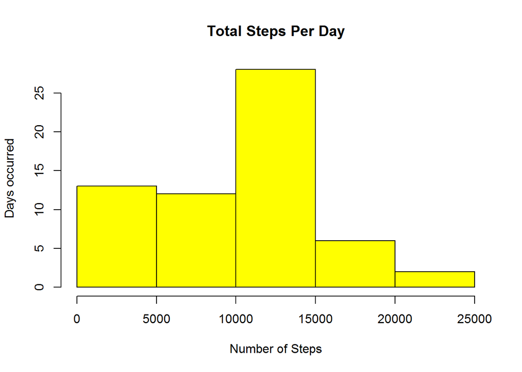

```r
    date_sums <- colSums(csv_wide, na.rm = TRUE)
    # It look slike the histogram might be flipped!
    # steps taken on the Y axis
    hist(date_sums, main="Total Steps Per Day", xlab="Number of Steps", ylab="Days occurred", col="yellow")
```

```r
    # Store the mean and median for later use
    ma <- mean(date_sums)
    md <- median(date_sums)
```

The above histogram agrees with the calculated results:

- The mean number of steps per day is **9354.2295082.**
- The median number of steps per day is **10395**.

## Part 2

### What is the average daily activity pattern?

The answer to this question can be derived from the data used above.

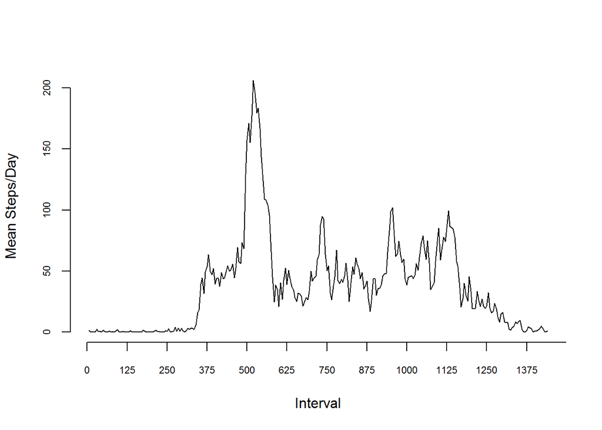

```r
    interval_means <- rowMeans(csv_wide, na.rm = TRUE)
    plot.ts(interval_means, type="l", ylab="Mean Steps/Day", xlab="Interval", axes=FALSE)

    # The plotter counts intervals instead of using the names
    # plus there isn't enough room to show them all, so, we'll generate a subset
    par(cex=0.7)
    xn <- seq(0, 13) * 25
    yn <- c(0, 50, 100, 150, 200)
    axis(1, at=xn, labels= as.character(xn * 5))
    axis(2, at=yn, labels=as.character(yn))
```

```r
    # repair
    par(cex=1.0)
```

**Question:** Which 5-minute interval, on average across all the days in the dataset, contains the maximum number of steps?

The answer to this question is found in the interval means calculated above.

```r
    location_of_max <- which.is.max(interval_means)
```

**Answer:** Interval **835** is the one with the most steps, on average, across all days, with a total of **206.1698113**.

## Part 3

### Imputing missing values

**Question:** How many missing values in the dataset?

```r
    missings <- is.na(csv$steps)
```

**Answer:** There are 2304 values missing from the dataset.

**Questions:** Devise a strategy for dealing with missing values and create a new dataset to implement it.

**Answer:** We can insert the previously calculated interval means in place of NAs, as follows:

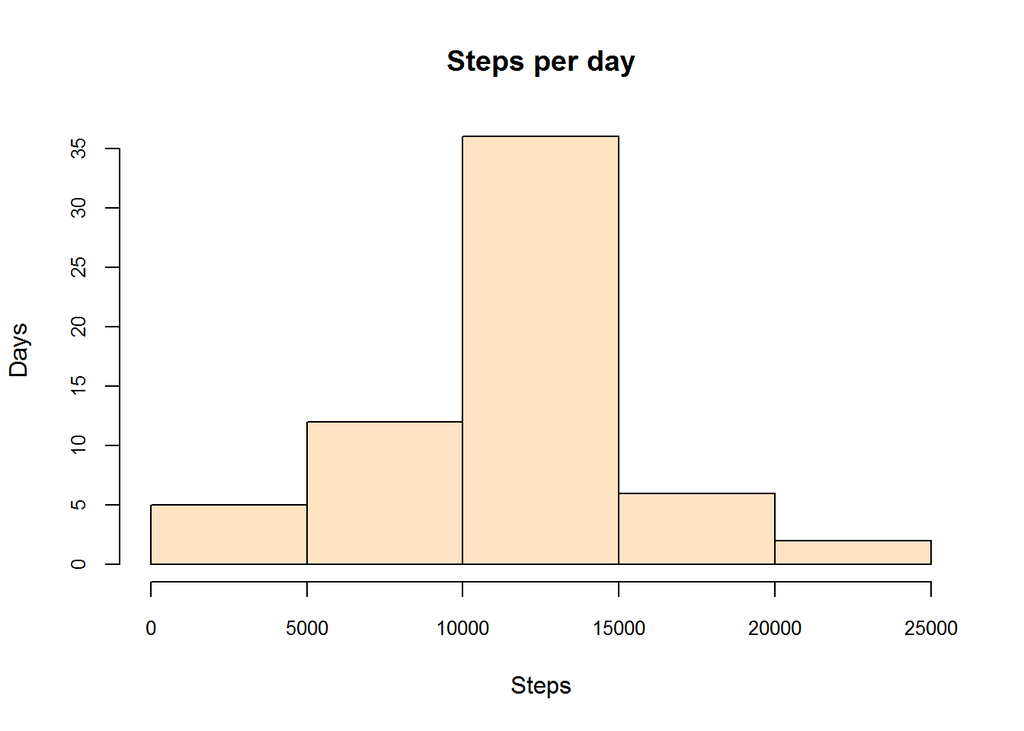

```r
    # This function will be called once per row on the original dataset
    imputer <- function(row, means) {
        if (is.na(row["steps"])) {
            row["steps"] <- means[toString(row["interval"])]
        }

        row
    }

    # AGAIN, I tried to find a more elegant R-ish way to do this
    # but couldn't quite get it to work, and there's a deadline
    # Sooooo, brute force wins again:
    csv_imputed <- csv
    for (i in 1:length(csv_imputed$steps)) {
        csv_imputed[i,] <- imputer(csv_imputed[i,], interval_means)
    }

    # NOW reshape the data the way it was done in part 1
    # and calculate and display the same things
    # we'll reuse the intervals and dates from before
    csvi_wide <- data.frame(matrix(ncol=length(dates), nrow=length(intervals)))
    colnames(csvi_wide) <- dates
    rownames(csvi_wide) <- intervals

    for (d in dates){
        # got a date. Sum every rsteps row in csv that matches
        term <- paste("SELECT steps from csv_imputed where date='", d, "'", sep="")
        dt <- sqldf(term)
        csvi_wide[,d] <- dt
    }

    # do the calculations needed to finish this section:
    date_sums_i <- colSums(csvi_wide)  # remove NAs no longer needed
    hist(date_sums_i, main="Steps per day", xlab="Steps", ylab="Days",
                      cex=0.7, col="bisque", axes=FALSE)
    xax <- c(0, 5000, 10000, 15000, 20000, 25000)
    yax <- c(0, 5, 10, 15, 20, 25, 30, 35)
    par(cex=0.8)
    axis(1, at=xax, labels=as.character(xax))
    axis(2, at=yax, labels=as.character(yax))
```

```r
    ma_i <- mean(date_sums_i)
    md_i <- median(date_sums_i)
    # repair:
    par(cex=1.0)
```

**Question:** How do the mean and median from this calculation compare with the ones done previously (before missing values were replaced)?

## Part 4

### Are there differences in activity patterns between weekdays and weekends?

The following function will help create the needed factor variable that we’ll use to separate weekends from weekdays.

```r
    weekend_or_not <- function(date_string){
        day <- weekdays(as.Date(date_string))
        which_day = "weekday"
        if (day == "Saturday" || day == "Sunday") {
            which_day = "weekend"
        }
        which_day
    }
```

Now to reshape the imputed dataset into a form that will make answering the question simple.

```r
    new_f <- data.frame(matrix(nrow=length(dates), ncol=length(intervals)))
    rownames(new_f) <- dates
    colnames(new_f) <- intervals
    factor_col <- c()
    for (d in dates) {
        term <- paste("SELECT steps from csv_imputed where date='", d, "'", sep="")
        new_col <- sqldf(term)

        # new_row is actually a data frame, so access it this way
        new_f[d,] <- new_col[,1]
        factor_col <- c(factor_col, weekend_or_not(d))
    }

    # have to add the factors all at once
    # or else R coerces all the values in the column to chraracter
    # This way keeps them as numbers
    new_f$day_type <- factor(factor_col, levels=c("weekend", "weekday"))
```

And display the plots.

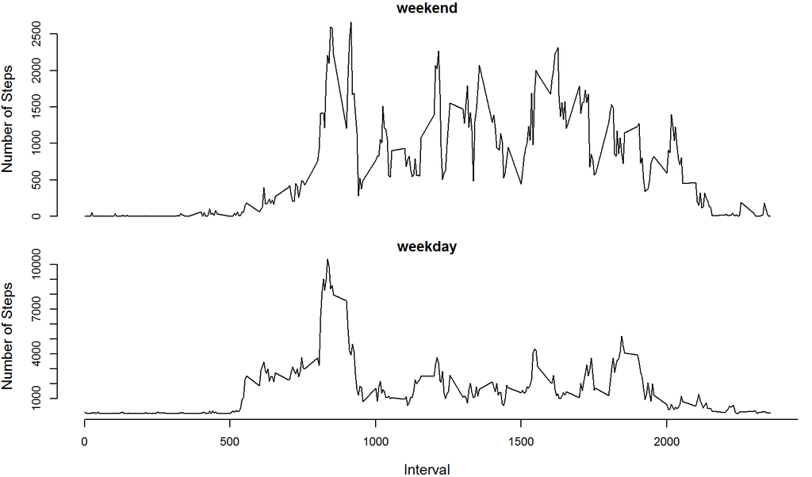

```r
weekend_data <- subset(new_f, day_type == "weekend", select=seq(1:288))
weekday_data <- subset(new_f, day_type == "weekday", select=seq(1:288))

# and now the plot. Sticking with standard plot, even though it's not as pretty.
# I get better results when I keep it simple.
# Though I'm giving up the title background color from the example.
par(mfrow=c(2,1), mar=c(1,4,1,1), cex=0.75)
label_sz = 1.2

yx1 <- c(0, 500, 1000, 1500, 2000, 2500)
plot.ts(colnames(weekend_data), colSums(weekend_data), type="l", axes=FALSE, xlab="", ylab="")
axis(2, at=yx1, labels=as.character(yx1))
title(main="weekend", ylab="Number of Steps", cex.lab=label_sz)

yx2 <- c(1000,2000, 3000, 4000, 5000, 6000, 7000, 8000, 9000, 10000)
xx2 <- c(0, 500, 1000, 1500, 2000, 2500)
par(mar=c(4,4,1,1))
plot.ts(colnames(weekday_data), colSums(weekday_data), type="l", axes=FALSE, xlab="", ylab="")
axis(2, at=yx2, labels=as.character(yx2))
axis(1, at=xx2, labels=as.character(xx2))
title(main="weekday")
title(xlab="Interval", cex.lab=label_sz, ylab="Number of Steps")
```

### Thus endeth the assignment